# Text analysis: fundamentals and sentiment analysis

MACS 30500 University of Chicago

## Basic workflow for text analysis

- Obtain your text sources
- Extract documents and move into a corpus
- Transformation
- Extract features
- Perform analysis

## Obtain your text sources

- Web sites
  - Twitter
- Databases
- PDF documents
- Digital scans of printed materials

## Extract documents and move into a corpus

- Text corpus
- Typically stores the text as a raw character string with metadata and details stored with the text

## Transformation

- Tag segments of speech for part-of-speech (nouns, verbs, adjectives, etc.) or entity recognition (person, place, company, etc.)
- Standard text processing
  - Convert to lower case
  - Remove punctuation
  - Remove numbers
  - Remove stopwords
  - Remove domain-specific stopwords
  - Stemming

## Extract features

- Convert the text string into some sort of quantifiable measures
- Bag-of-words model
  - Term frequency vector
  - Term-document matrix
  - Ignores context

## Perform analysis

- Basic
  - Word frequency
  - Collocation
  - Dictionary tagging
- Advanced
  - Document classification
    - Supervised
    - Unsupervised
  - Corpora comparison
  - Topic modeling

## [`tidytext`](https://github.com/juliasilge/tidytext)

- Tidy text format
- Defined as one-term-per-row
- Differs from the term-document matrix
  - One-document-per-row and one-term-per-column

## Get text corpa

```r
library(janeaustenr)

books <- austen_books() %>%
  group_by(book) %>%
  mutate(linenumber = row_number(),
         chapter = cumsum(str_detect(text,
                                     regex("^chapter [\\divxlc]",
                                           ignore_case = TRUE)))) %>%
  ungroup()
books
```

```
## # A tibble: 73,422 x 4
##    text                  book                linenumber chapter
##    <chr>                 <fct>                    <int>   <int>
##  1 SENSE AND SENSIBILITY Sense & Sensibility          1       0
##  2 ""                    Sense & Sensibility          2       0
##  3 by Jane Austen        Sense & Sensibility          3       0
##  4 ""                    Sense & Sensibility          4       0
##  5 (1811)                Sense & Sensibility          5       0
##  6 ""                    Sense & Sensibility          6       0
##  7 ""                    Sense & Sensibility          7       0
##  8 ""                    Sense & Sensibility          8       0
##  9 ""                    Sense & Sensibility          9       0
## 10 CHAPTER 1             Sense & Sensibility         10       1
## # ... with 73,412 more rows
```

## Tokenize text

```r
tidy_books <- books %>%
  unnest_tokens(output = word, input = text)
tidy_books
```

```
## # A tibble: 725,055 x 4
##    book                linenumber chapter word
##    <fct>                    <int>   <int> <chr>
##  1 Sense & Sensibility          1       0 sense
##  2 Sense & Sensibility          1       0 and
##  3 Sense & Sensibility          1       0 sensibility
##  4 Sense & Sensibility          3       0 by
##  5 Sense & Sensibility          3       0 jane
##  6 Sense & Sensibility          3       0 austen
##  7 Sense & Sensibility          5       0 1811
##  8 Sense & Sensibility         10       1 chapter
##  9 Sense & Sensibility         10       1 1
## 10 Sense & Sensibility         13       1 the
## # ... with 725,045 more rows
```

## Download population data for U.S. states

```r
# retrieve state populations in 2016 from Census Bureau
pop_df <- read_csv("../data/pop2016.csv")

# do these results make sense?
pop_df %>%
  arrange(desc(population)) %>%
  top_n(10)
```

```
## # A tibble: 10 x 3
##    GEOID state_name     population
##    <chr> <chr>               <int>
##  1 06    california       38654206
##  2 48    texas            26956435
##  3 12    florida          19934451
##  4 36    new york         19697457
##  5 17    illinois         12851684
##  6 42    pennsylvania     12783977
##  7 39    ohio             11586941
##  8 13    georgia          10099320
##  9 37    north carolina    9940828
## 10 26    michigan          9909600
```

## Retrieve song lyrics

```r
song_lyrics <- read_csv("../data/billboard_lyrics_1964-2015.csv")
glimpse(song_lyrics)
```

```
## Observations: 5,100
## Variables: 6
## $ Rank   <int> 1, 2, 3, 4, 5, 6, 7, 8, 9, 10, 11, 12, 13, 14, 15, 16, ...
## $ Song   <chr> "wooly bully", "i cant help myself sugar pie honey bunc...
## $ Artist <chr> "sam the sham and the pharaohs", "four tops", "the roll...
## $ Year   <int> 1965, 1965, 1965, 1965, 1965, 1965, 1965, 1965, 1965, 1...
## $ Lyrics <chr> "sam the sham miscellaneous wooly bully wooly bully sam...
## $ Source <int> 3, 1, 1, 1, 1, 1, 3, 5, 1, 3, 3, 1, 3, 1, 3, 3, 3, 3, 1...
```

> Use `tidytext` to create a data frame with one row for each token in each song

## Use `tidytext` to create a data frame with one row for each token in each song

```r
tidy_lyrics <- bind_rows(song_lyrics %>%
                           unnest_tokens(output = state_name,
                                         input = Lyrics),
                         song_lyrics %>%
                           unnest_tokens(output = state_name,
                                         input = Lyrics,
                                         token = "ngrams", n = 2))
tidy_lyrics
```

```
## # A tibble: 3,201,465 x 6
##     Rank Song        Artist                       Year Source state_name
##    <int> <chr>       <chr>                       <int>  <int> <chr>
##  1     1 wooly bully sam the sham and the phara…  1965      3 sam
##  2     1 wooly bully sam the sham and the phara…  1965      3 the
##  3     1 wooly bully sam the sham and the phara…  1965      3 sham
##  4     1 wooly bully sam the sham and the phara…  1965      3 miscellaneo…
##  5     1 wooly bully sam the sham and the phara…  1965      3 wooly
##  6     1 wooly bully sam the sham and the phara…  1965      3 bully
##  7     1 wooly bully sam the sham and the phara…  1965      3 wooly
##  8     1 wooly bully sam the sham and the phara…  1965      3 bully
##  9     1 wooly bully sam the sham and the phara…  1965      3 sam
## 10     1 wooly bully sam the sham and the phara…  1965      3 the
## # ... with 3,201,455 more rows
```

> Find all the state names occurring in the song lyrics

## Find all the state names occurring in the song lyrics

```r
tidy_lyrics <- inner_join(tidy_lyrics, pop_df) %>%
  distinct(Rank, Song, Artist, Year, state_name, .keep_all = TRUE)
tidy_lyrics
```

```
## # A tibble: 253 x 8
##     Rank Song        Artist        Year Source state_name GEOID population
##    <int> <chr>       <chr>        <int>  <int> <chr>      <chr>      <int>
##  1    12 king of th… roger miller  1965      1 maine      23       1329923
##  2    29 eve of des… barry mcgui…  1965      1 alabama    01       4841164
##  3    49 california… the beach b…  1965      3 california 06      38654206
##  4    10 california… the mamas  …  1966      3 california 06      38654206
##  5    77 message to… dionne warw…  1966      1 kentucky   21       4411989
##  6    61 california… lesley gore   1967      1 california 06      38654206
##  7     4 sittin on … otis redding  1968      1 georgia    13      10099320
##  8    10 tighten up  archie bell…  1968      3 texas      48      26956435
##  9    25 get back    the beatles…  1969      3 arizona    04       6728577
## 10    25 get back    the beatles…  1969      3 california 06      38654206
## # ... with 243 more rows
```

> Calculate the frequency for each state’s mention in a song and create a new column for the frequency adjusted by the state’s population

## Calculate the frequency for each state’s mention in a song and create a new column for the frequency adjusted by the state’s population

```r
(state_counts <- tidy_lyrics %>%
   count(state_name) %>%
   arrange(desc(n)))
```

```
## # A tibble: 33 x 2
##    state_name      n
##    <chr>       <int>
##  1 new york       64
##  2 california     34
##  3 georgia        22
##  4 tennessee      14
##  5 texas          14
##  6 alabama        12
##  7 mississippi    10
##  8 kentucky        7
##  9 hawaii          6
## 10 illinois        6
## # ... with 23 more rows
```

```r
pop_df <- pop_df %>%
  left_join(state_counts) %>%
  mutate(rate = n / population * 1e6)

pop_df %>%
  arrange(desc(rate)) %>%
  top_n(10)
```

```
## # A tibble: 10 x 5
##    GEOID state_name  population     n  rate
##    <chr> <chr>            <int> <int> <dbl>
##  1 15    hawaii         1413673     6  4.24
##  2 28    mississippi    2989192    10  3.35
##  3 36    new york      19697457    64  3.25
##  4 01    alabama        4841164    12  2.48
##  5 23    maine          1329923     3  2.26
##  6 13    georgia       10099320    22  2.18
##  7 47    tennessee      6548009    14  2.14
##  8 30    montana        1023391     2  1.95
##  9 31    nebraska       1881259     3  1.59
## 10 21    kentucky       4411989     7  1.59
```

## Make a choropleth map for both the raw frequency counts and relative frequency counts

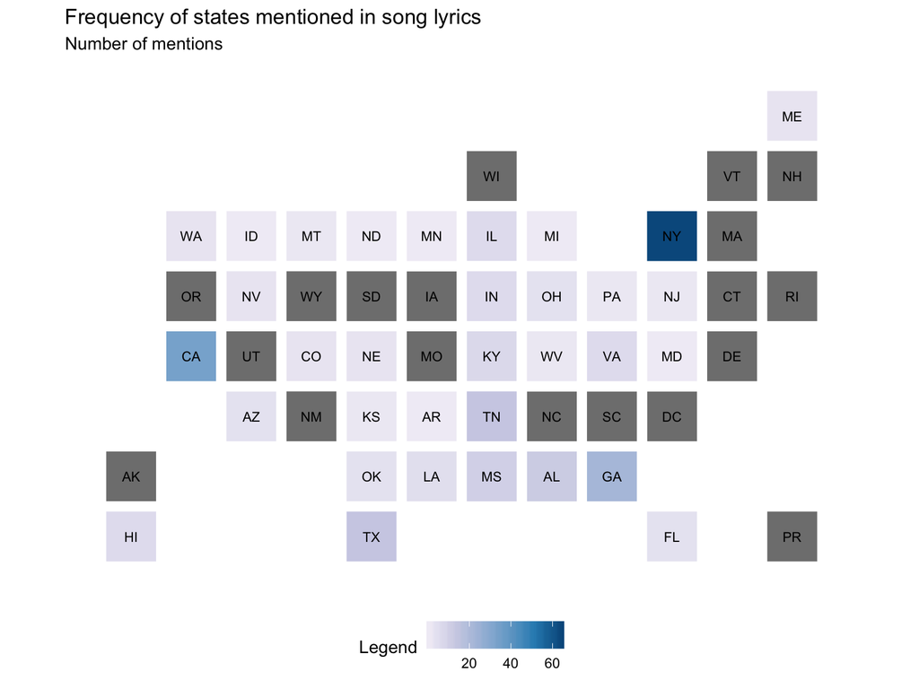

```r
library(statebins)

pop_df %>%
  mutate(state_name = stringr::str_to_title(state_name),
         state_name = if_else(state_name == "District Of Columbia",
                              "District of Columbia", state_name)) %>%
  statebins_continuous(state_col = "state_name", value_col = "n") +
  labs(title = "Frequency of states mentioned in song lyrics",
       subtitle = "Number of mentions") +
  theme(legend.position = "bottom")
```

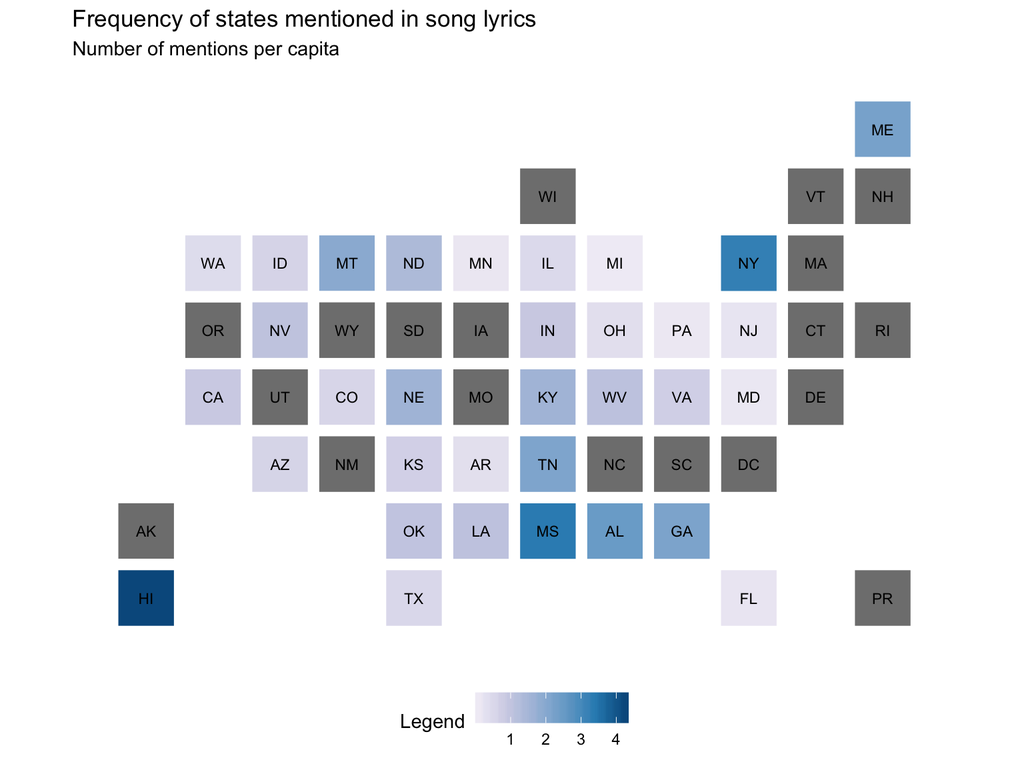

```r
pop_df %>%
  mutate(state_name = stringr::str_to_title(state_name),
         state_name = if_else(state_name == "District Of Columbia",
                              "District of Columbia", state_name)) %>%
  statebins_continuous(state_col = "state_name", value_col = "rate") +
  labs(title = "Frequency of states mentioned in song lyrics",
       subtitle = "Number of mentions per capita") +
  theme(legend.position = "bottom")
```

## Sentiment analysis

> I am happy

## Dictionaries

```r
get_sentiments("bing")
```

```
## # A tibble: 6,788 x 2
##    word        sentiment
##    <chr>       <chr>
##  1 2-faced     negative
##  2 2-faces     negative
##  3 a+          positive
##  4 abnormal    negative
##  5 abolish     negative
##  6 abominable  negative
##  7 abominably  negative
##  8 abominate   negative
##  9 abomination negative
## 10 abort       negative
## # ... with 6,778 more rows
```

## Dictionaries

```r
get_sentiments("afinn")
```

```
## # A tibble: 2,476 x 2
##    word       score
##    <chr>      <int>
##  1 abandon       -2
##  2 abandoned     -2
##  3 abandons      -2
##  4 abducted      -2
##  5 abduction     -2
##  6 abductions    -2
##  7 abhor         -3
##  8 abhorred      -3
##  9 abhorrent     -3
## 10 abhors        -3
## # ... with 2,466 more rows
```

## Dictionaries

```r
get_sentiments("nrc")
```

```
## # A tibble: 13,901 x 2
##    word        sentiment
##    <chr>       <chr>
##  1 abacus      trust
##  2 abandon     fear
##  3 abandon     negative
##  4 abandon     sadness
##  5 abandoned   anger
##  6 abandoned   fear
##  7 abandoned   negative
##  8 abandoned   sadness
##  9 abandonment anger
## 10 abandonment fear
## # ... with 13,891 more rows
```

## Dictionaries

```r
get_sentiments("nrc") %>%
  count(sentiment)
```

```
## # A tibble: 10 x 2
##    sentiment        n
##    <chr>        <int>
##  1 anger         1247
##  2 anticipation   839
##  3 disgust       1058
##  4 fear          1476
##  5 joy            689
##  6 negative      3324
##  7 positive      2312
##  8 sadness       1191
##  9 surprise       534
## 10 trust         1231
```

## Calculate sentiment

```r
tidy_books %>%
  inner_join(get_sentiments("bing"))
```

```
## # A tibble: 52,287 x 5
##    book                linenumber chapter word        sentiment
##    <fct>                    <int>   <int> <chr>       <chr>
##  1 Sense & Sensibility         16       1 respectable positive
##  2 Sense & Sensibility         16       1 good        positive
##  3 Sense & Sensibility         18       1 advanced    positive
##  4 Sense & Sensibility         20       1 death       negative
##  5 Sense & Sensibility         20       1 great       positive
##  6 Sense & Sensibility         21       1 loss        negative
##  7 Sense & Sensibility         25       1 comfortably positive
##  8 Sense & Sensibility         28       1 goodness    positive
##  9 Sense & Sensibility         28       1 solid       positive
## 10 Sense & Sensibility         29       1 comfort     positive
## # ... with 52,277 more rows
```

```r
tidy_books %>%
  inner_join(get_sentiments("bing")) %>%
  count(book, index = linenumber %/% 80, sentiment)
```

```
## # A tibble: 1,840 x 4
##    book                index sentiment     n
##    <fct>               <dbl> <chr>     <int>
##  1 Sense & Sensibility     0 negative     16
##  2 Sense & Sensibility     0 positive     32
##  3 Sense & Sensibility     1 negative     19
##  4 Sense & Sensibility     1 positive     53
##  5 Sense & Sensibility     2 negative     12
##  6 Sense & Sensibility     2 positive     31
##  7 Sense & Sensibility     3 negative     15
##  8 Sense & Sensibility     3 positive     31
##  9 Sense & Sensibility     4 negative     16
## 10 Sense & Sensibility     4 positive     34
## # ... with 1,830 more rows
```

```r
tidy_books %>%
  inner_join(get_sentiments("bing")) %>%
  count(book, index = linenumber %/% 80, sentiment) %>%
  spread(sentiment, n, fill = 0)
```

```
## # A tibble: 920 x 4
##    book                index negative positive
##    <fct>               <dbl>    <dbl>    <dbl>
##  1 Sense & Sensibility     0       16       32
##  2 Sense & Sensibility     1       19       53
##  3 Sense & Sensibility     2       12       31
##  4 Sense & Sensibility     3       15       31
##  5 Sense & Sensibility     4       16       34
##  6 Sense & Sensibility     5       16       51
##  7 Sense & Sensibility     6       24       40
##  8 Sense & Sensibility     7       23       51
##  9 Sense & Sensibility     8       30       40
## 10 Sense & Sensibility     9       15       19
## # ... with 910 more rows
```

```r
tidy_books %>%
  inner_join(get_sentiments("bing")) %>%
  count(book, index = linenumber %/% 80, sentiment) %>%
  spread(sentiment, n, fill = 0) %>%
  mutate(sentiment = positive - negative)
```

```
## # A tibble: 920 x 5
##    book                index negative positive sentiment
##    <fct>               <dbl>    <dbl>    <dbl>     <dbl>
##  1 Sense & Sensibility     0       16       32        16
##  2 Sense & Sensibility     1       19       53        34
##  3 Sense & Sensibility     2       12       31        19
##  4 Sense & Sensibility     3       15       31        16
##  5 Sense & Sensibility     4       16       34        18
##  6 Sense & Sensibility     5       16       51        35
##  7 Sense & Sensibility     6       24       40        16
##  8 Sense & Sensibility     7       23       51        28
##  9 Sense & Sensibility     8       30       40        10
## 10 Sense & Sensibility     9       15       19         4
## # ... with 910 more rows
```

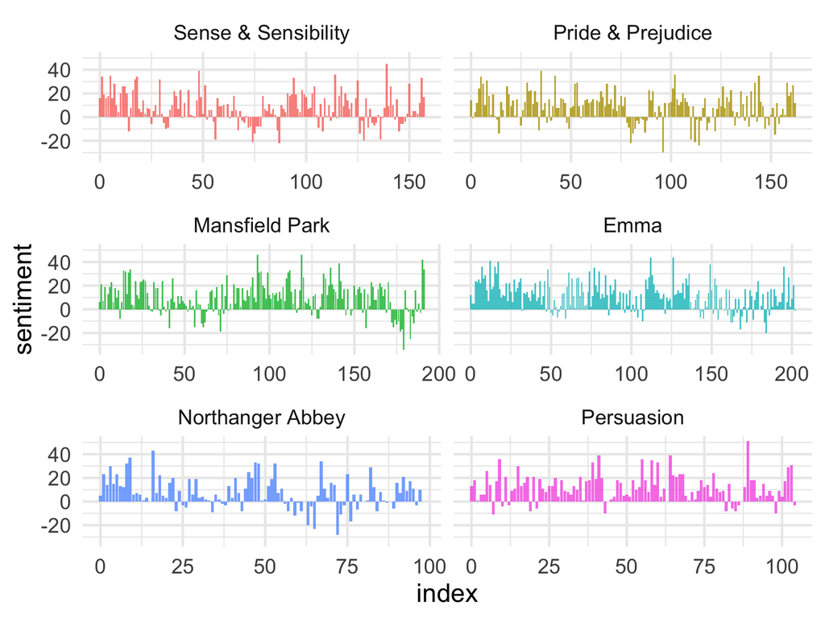

```r
janeaustensentiment <- tidy_books %>%
  inner_join(get_sentiments("bing")) %>%
  count(book, index = linenumber %/% 80, sentiment) %>%
  spread(sentiment, n, fill = 0) %>%
  mutate(sentiment = positive - negative)

# plot the sentiment over time in each book
ggplot(janeaustensentiment, aes(index, sentiment, fill = book)) +
        geom_bar(alpha = 0.8, stat = "identity", show.legend = FALSE) +
        facet_wrap( ~ book, ncol = 2, scales = "free_x")
```

## Load Harry Potter text

```
## # A tibble: 1,089,386 x 3
## # Groups:   book [7]
##    book               chapter word
##    <fct>                <int> <chr>
##  1 philosophers_stone       1 the
##  2 philosophers_stone       1 boy
##  3 philosophers_stone       1 who
##  4 philosophers_stone       1 lived
##  5 philosophers_stone       1 mr
##  6 philosophers_stone       1 and
##  7 philosophers_stone       1 mrs
##  8 philosophers_stone       1 dursley
##  9 philosophers_stone       1 of
## 10 philosophers_stone       1 number
## # ... with 1,089,376 more rows
```

## Most frequent words, by book

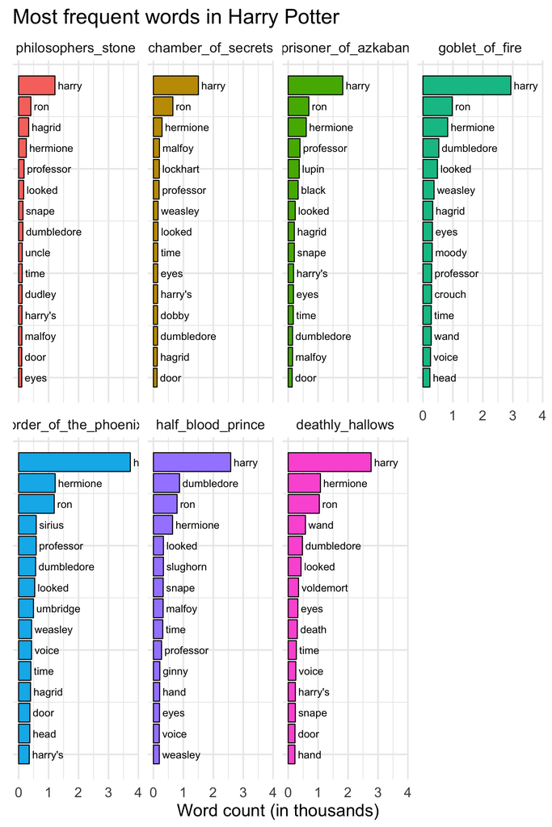

## Exercises

[figure not shown]